# ANÁLISIS DE DATOS ÓMICOS, PEC 1

Carlos Fernandez Medina

2 de mayo de 2020

# 1 Abstract

La proteína cremallera de leucina específica de la retina neural de los bastones (Nrl) es fundamental para la diferenciación de estos fotorreceptores. En esta investigación se pretende estudiar la diferencia de expresión génica entre ratones silvestres (WT) y deficientes de la proteína (KO) en tres puntos de su ciclo de vida. Esto permitirá identificar posibles genes implicados en enfermedades relacionadas con la ausencia de bastones.

# 2 Objetivos

En este estudio se pretende describir la diferencia de expresión génica entre ratones con Nrl (WT) y sin Nrl (Nrl KO) en tres etapas de la vida, concretamente a los dos días de vida (P2), a los diez días de vida (P10) y a los dos meses de vida (2). Además, se pretende conocer los genes que pudieran estar relacionados con enfermedades relacionadas con la ausencia de bastones.

# 3 Materiales, métodos y resultados

## 3.1 Datos

Los datos se obtuvieron del análisis de expresión de RNA de retinas de ratones sin bastones Nrl knock-out (KO) y de ratones silvestres (WT) y se llevó a cabo mediante microarrays de Affymetrix MICROARRAY SUITE v5.0. Los datos obtenidos se pueden consultar en la base de datos “*Gene Expression Omnibus*” (GEO), serie GSE8972.

```r
setwd("C:/Users/Carlos/Documents/MÁSTER BIOINFORMÁTICA - UOC/Análisis de Datos Ómicos/PEC_1_CarlosFdez/")
```

```r
require(oligo)
celfiles <- list.celfiles("./data", full.names=TRUE) #importamos ficheros
require (Biobase)
my.targets <-read.AnnotatedDataFrame(file.path("./data","targets.csv"),
                                  header = TRUE, row.names = 1, sep=";")
rawData <- read.celfiles(celfiles, phenoData = my.targets)
```

```r
my.targets@data$ShortName->rownames(pData(rawData))
colnames(rawData) <-rownames(pData(rawData))

head(rawData)
```

```
## ExpressionFeatureSet (storageMode: lockedEnvironment)
## assayData: 1 features, 24 samples
##   element names: exprs
## protocolData
##   rowNames: KO.P2.1 KO.P2.2 ... WT.2.4 (24 total)
##   varLabels: exprs dates
##   varMetadata: labelDescription channel
## phenoData
##   rowNames: KO.P2.1 KO.P2.2 ... WT.2.4 (24 total)
##   varLabels: Age Genotype ... ShortName (5 total)
##   varMetadata: labelDescription channel
## featureData: none
## experimentData: use 'experimentData(object)'
## Annotation: pd.mg.u74av2
```

## 3.2 Procedimiento general de análisis (pasos, “workflow” o “pipeline”)

1. Identificar que grupos hay y a qué grupo pertenece cada muestra
2. Control de calidad de los datos brutos
3. Normalización
4. Control de calidad de los datos normalizados
5. Filtraje no específico
6. Identificación de genes diferencialmente expresados
7. Anotación de los resultados
8. Comparación entre distintas comparaciones
9. Análisis de significación biológica

### 3.2.1 Identificar que grupos hay y a qué grupo pertenece cada muestra

En este estudio se diferencian seis grupos dependiendo de si presenta (WT) o no (KO) la proteína y de la fase de vida del ratón, dos días (P2), diez días (P10) o dos meses (2).

```r
targets <- read.csv2("./data/targets.csv", header = TRUE, sep = ";")
knitr::kable(
  targets, booktabs = TRUE,
  caption = 'Relación de ficheros usados para este análisis')
```

Relación de ficheros usados para este análisis

| Samples | Age | Genotype | Title | Group | ShortName |
| --- | --- | --- | --- | --- | --- |
| GSM227448 | 2 d | KO | Nrl ko P2 replicate 1 | KO.P2 | KO.P2.1 |
| GSM227449 | 2 d | KO | Nrl ko P2 replicate 2 | KO.P2 | KO.P2.2 |
| GSM227450 | 2 d | KO | Nrl ko P2 replicate 3 | KO.P2 | KO.P2.3 |
| GSM227451 | 2 d | KO | Nrl ko P2 replicate 4 | KO.P2 | KO.P2.4 |
| GSM227452 | 2 d | WT | WT P2 replicate 1 | WT.P2 | WT.P2.1 |
| GSM227453 | 2 d | WT | WT P2 replicate 2 | WT.P2 | WT.P2.2 |
| GSM227454 | 2 d | WT | WT P2 replicate 3 | WT.P2 | WT.P2.3 |
| GSM227455 | 2 d | WT | WT P2 replicate 4 | WT.P2 | WT.P2.4 |
| GSM227456 | 10 d | KO | Nrl ko P10 replicate 1 | KO.P10 | KO.P10.1 |
| GSM227457 | 10 d | KO | Nrl ko P10 replicate 2 | KO.P10 | KO.P10.2 |
| GSM227458 | 10 d | KO | Nrl ko P10 replicate 3 | KO.P10 | KO.P10.3 |
| GSM227459 | 10 d | KO | Nrl ko P10 replicate 4 | KO.P10 | KO.P10.4 |
| GSM227460 | 10 d | WT | WT P10 replicate 1 | WT.P10 | WT.P10.1 |
| GSM227461 | 10 d | WT | WT P10 replicate 2 | WT.P10 | WT.P10.2 |
| GSM227462 | 10 d | WT | WT P10 replicate 3 | WT.P10 | WT.P10.3 |
| GSM227463 | 10 d | WT | WT P10 replicate 4 | WT.P10 | WT.P10.4 |
| GSM227464 | 2 mo | KO | Nrl ko 2 mon replicate 1 | KO.2 | KO.2.1 |
| GSM227465 | 2 mo | KO | Nrl ko 2 mon replicate 2 | KO.2 | KO.2.2 |
| GSM227466 | 2 mo | KO | Nrl ko 2 mon replicate 3 | KO.2 | KO.2.3 |
| GSM227467 | 2 mo | KO | Nrl ko 2 mon replicate 4 | KO.2 | KO.2.4 |
| GSM227468 | 2 mo | WT | WT 2 mon replicate 1 | WT.2 | WT.2.1 |
| GSM227469 | 2 mo | WT | WT 2 mon replicate 2 | WT.2 | WT.2.2 |
| GSM227470 | 2 mo | WT | WT 2 mon replicate 3 | WT.2 | WT.2.3 |
| GSM227471 | 2 mo | WT | WT 2 mon replicate 4 | WT.2 | WT.2.4 |

### 3.2.2 Control de calidad de los datos brutos

Para el control de calidad de los datos brutos se lleva a cabo un análisis mediante el método “Principal Component Analysis” (PCA) y mediante gráficos de cajas (“boxplots”). Además, se obtienen gráficos ejecutando la librería `arrayQualityMetrics`.

```r
library(arrayQualityMetrics)
arrayQualityMetrics(rawData)
```

```r
require(ggplot2)
require(ggrepel)
plotPCA <- function (datos, labels, factor, title, scale,colores, size = 1.5, glineas = 0.25) {
  data <- prcomp(t(datos),scale=scale)
  # plot adjustments
  dataDf <- data.frame(data$x)
  Group <- factor
  loads <- round(data$sdev^2/sum(data$sdev^2)*100,1)
  # main plot
  p1 <- ggplot(dataDf,aes(x=PC1, y=PC2)) +
    theme_classic() +
    geom_hline(yintercept = 0, color = "gray70") +
    geom_vline(xintercept = 0, color = "gray70") +
    geom_point(aes(color = Group), alpha = 0.55, size = 3) +
    coord_cartesian(xlim = c(min(data$x[,1])-5,max(data$x[,1])+5)) +
    scale_fill_discrete(name = "Group")
  # avoiding labels superposition
  p1 + geom_text_repel(aes(y = PC2 + 0.25, label = labels),segment.size = 0.25, size = size) +
    labs(x = c(paste("PC1",loads[1],"%")),y=c(paste("PC2",loads[2],"%"))) +
    ggtitle(paste("Principal Component Analysis para: ",title,sep=" "))+
    theme(plot.title = element_text(hjust = 0.5)) +
    scale_color_manual(values=colores)
  }
```

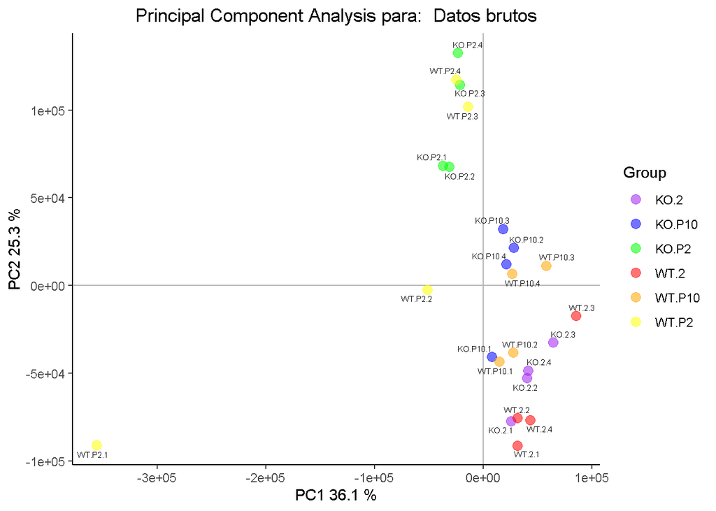

```r
plotPCA(exprs(rawData), labels = targets$ShortName, factor = targets$Group,
         title="Datos brutos", scale = FALSE, size = 2,
         colores = c("purple", "blue", "green", "red", "orange", "yellow"))
```

Guardamos esta gráfica en nuestro directorio de trabajo.

```r
tiff("figuras/PCA_RawData.tiff", res = 200, width = 4.5, height = 4, units = 'in')
plotPCA(exprs(rawData), labels = targets$ShortName, factor = targets$Group,
         title="Datos brutos", scale = FALSE, size = 2,
         colores = c("purple", "blue", "green", "red", "orange", "yellow"))
dev.off()
```

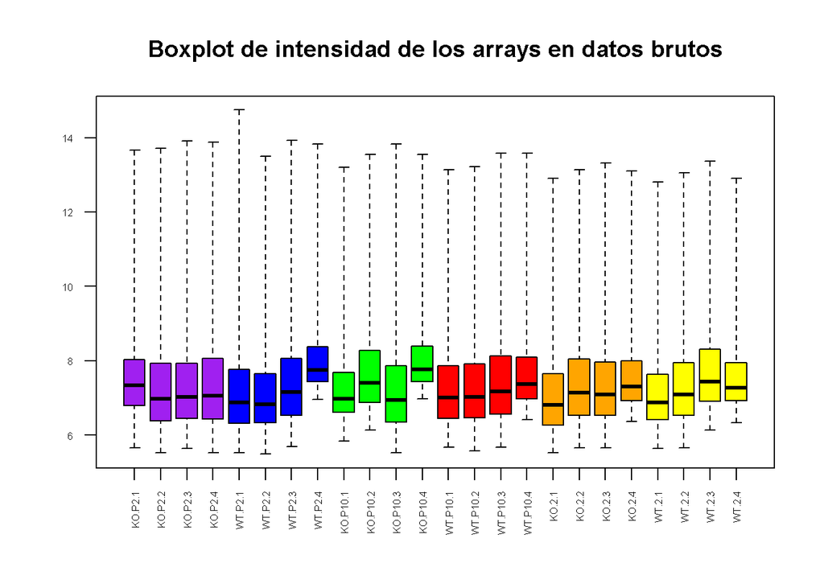

```r
boxplot(rawData, cex.axis=0.5, las=2,  which="all",
         col = c(rep("purple", 4), rep("blue", 4), rep("green", 4), rep("red", 4), rep("orange", 4), rep("yellow", 4)),
         main="Boxplot de intensidad de los arrays en datos brutos")
```

Con el primer gráfico de cajas podemos ver ligeras variaciones en los valores de intensidad, lo cual es normal en el análisis de datos crudos.

### 3.2.3 Normalización

Aplicamos el método más utilizado para la normalización de los datos: “Robust Multichip Average” (RMA).

```r
esetRma <- rma(rawData)
```

```
## Background correcting
## Normalizing
## Calculating Expression
```

### 3.2.4 Control de calidad de los datos normalizados

Primero, realizamos de nuevo un diagrama PCA para observar las variaciones tras la normalización de los datos:

```r
arrayQualityMetrics(esetRma, outdir = file.path("./results", "QCDir.Norm"), force=TRUE)
```

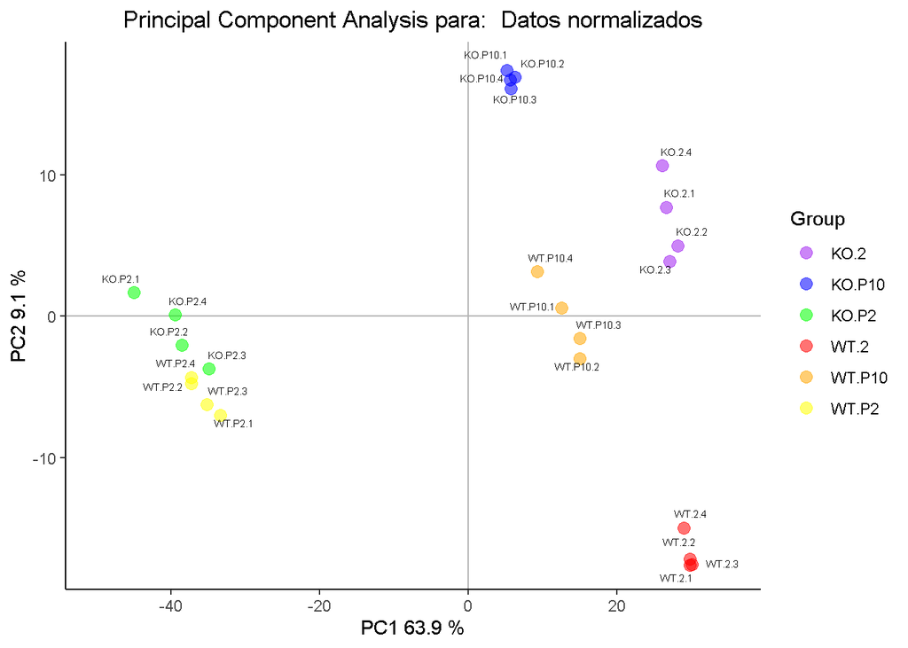

Visualization of first two principal components for normalized data

```r
plotPCA(exprs(esetRma), labels = targets$ShortName, factor = targets$Group,
         title="Datos normalizados", scale = FALSE, size = 2,
         colores = c("purple", "blue", "green", "red", "orange", "yellow"))
```

Podemos observar que el primer componente presenta el 63.9% de la variabilidad, valor que ha aumentado con respecto a los datos brutos. Esto Sigue debiéndose a las muestras de P10 y 2. Ahora se ven más agrupadas las muestras de los seis diferentes grupos.

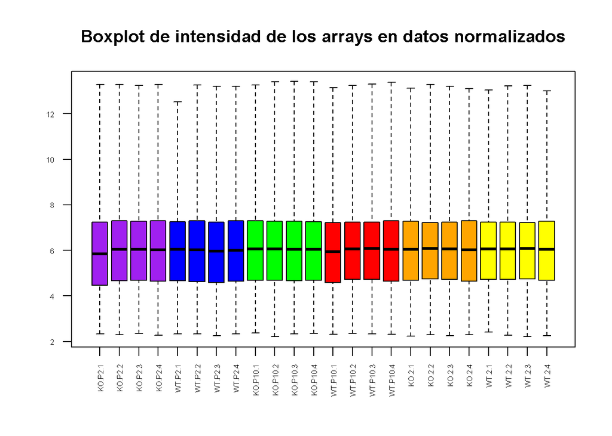

```r
boxplot(esetRma, cex.axis=0.5, las=2,  which="all",
         col = c(rep("purple", 4), rep("blue", 4), rep("green", 4), rep("red", 4), rep("orange", 4), rep("yellow", 4)),
         main="Boxplot de intensidad de los arrays en datos normalizados")
```

Ahora los diagramas de caja son muy similares y apenas hay diferencias.

Por útlimo, llevamos a cabo un análisis de (PCVA), un tipo de los llamados “Batch Detection” con el fin de observar qué factores (efectos) están involucrados con la variabilidad de la expresión de los genes.

```r
#load the library
require(pvca)
pData(esetRma) <- targets
#select the threshold
pct_threshold <- 0.6
#select the factors to analyze
batch.factors <- c("Genotype", "Age")
#run the analysis
pvcaObj <- pvcaBatchAssess (esetRma, batch.factors, pct_threshold)
```

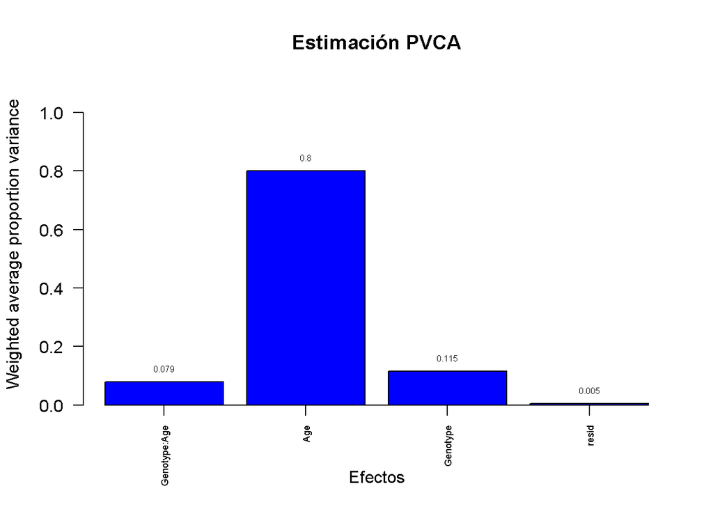

```r
bp <- barplot(pvcaObj$dat, xlab = "Efectos",
  ylab = "Weighted average proportion variance",
  ylim= c(0,1.1),col = c("blue"), las=2,
  main="Estimación PVCA")
axis(1, at = bp, labels = pvcaObj$label, cex.axis = 0.55, las=2)
values = pvcaObj$dat
new_values = round(values , 3)
text(bp,pvcaObj$dat,labels = new_values, pos=3, cex = 0.5)
```

En esta gráfica sobre la estimación PVCA podemos observar que el efecto “Age” (edad) es el principal responsable de la variación.

### 3.2.5 Filtraje no específico

Primero, clasificamos los genes según su variabilidad:

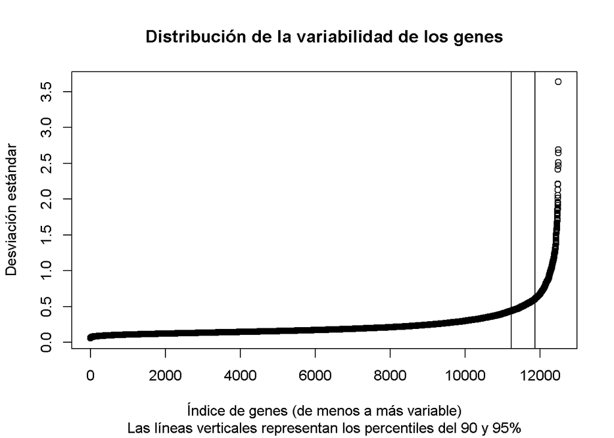

```r
sds <- apply (exprs(esetRma), 1, sd)
sdsO<- sort(sds)
plot(1:length(sdsO), sdsO, main="Distribución de la variabilidad de los genes",
     sub="Las líneas verticales representan los percentiles del 90 y 95%",
     xlab="Índice de genes (de menos a más variable)", ylab="Desviación estándar")
abline(v=length(sds)*c(0.9,0.95))
```

Tras ello, filtramos los genes con menor variabilidad y los eliminamos:

```r
require(genefilter)
require(mogene21sttranscriptcluster.db)
require(mgu74av2.db)
annotation(esetRma) <- "mgu74av2.db"
filtered <- nsFilter(esetRma,
                     require.entrez = TRUE, remove.dupEntrez = TRUE,
                     var.filter=TRUE, var.func=IQR, var.cutoff=0.75,
                     filterByQuantile=TRUE, feature.exclude = "^AFFX")
```

Eliminamos lo genes con menos variabilidad y que su variabilidad puede ser aleatoria.

```r
print(filtered$filter.log)
```

```
## $numDupsRemoved
## [1] 2639
##
## $numLowVar
## [1] 6526
##
## $numRemoved.ENTREZID
## [1] 1125
##
## $feature.exclude
## [1] 22
```

```r
esetFiltered <-filtered$eset
```

Guardamos los datos normalizados y filtrados:

```r
write.csv(exprs(esetRma), file="./results/normalized.Data.csv")
write.csv(exprs(esetFiltered), file="./results/normalized.Filtered.Data.csv")
save(esetRma, esetFiltered, file="./results/normalized.Data.Rda")
```

### 3.2.6 Identificación de genes diferencialmente expresados

Primero, definiminos la matriz de diseño con los datos filtrados y normalizados:

```r
if (!exists("esetFiltered")) load (file="./results/normalized.Data.Rda")
```

```r
require(limma)
designMat<- model.matrix(~0+Group, pData(esetFiltered))
colnames(designMat) <- c("KO.2", "KO.P10", "KO.P2", "WT.2", "WT.P10", "WT.P2")
print(designMat)
```

```
##    KO.2 KO.P10 KO.P2 WT.2 WT.P10 WT.P2
## 1     0      0     1    0      0     0
## 2     0      0     1    0      0     0
## 3     0      0     1    0      0     0
## 4     0      0     1    0      0     0
## 5     0      0     0    0      0     1
## 6     0      0     0    0      0     1
## 7     0      0     0    0      0     1
## 8     0      0     0    0      0     1
## 9     0      1     0    0      0     0
## 10    0      1     0    0      0     0
## 11    0      1     0    0      0     0
## 12    0      1     0    0      0     0
## 13    0      0     0    0      1     0
## 14    0      0     0    0      1     0
## 15    0      0     0    0      1     0
## 16    0      0     0    0      1     0
## 17    1      0     0    0      0     0
## 18    1      0     0    0      0     0
## 19    1      0     0    0      0     0
## 20    1      0     0    0      0     0
## 21    0      0     0    1      0     0
## 22    0      0     0    1      0     0
## 23    0      0     0    1      0     0
## 24    0      0     0    1      0     0
## attr(,"assign")
## [1] 1 1 1 1 1 1
## attr(,"contrasts")
## attr(,"contrasts")$Group
## [1] "contr.treatment"
```

Tras ello, realizamos una matriz de contrastes para definir seis comparaciones, una entre KO y WT en P2 (`KOvsWT.P2`), otra entre KO y WT en P10(`KOvsWT.P10`), otra entre KO y WT en 2 (`KOvsWT.2`) y tres comparaciones entre los tres anteriores (`INT.1`, `INT.2` e `INT.3`):

```r
cont.matrix <- makeContrasts (KOvsWT.2 = KO.2-WT.2,
                              KOvsWT.P10 = KO.P10-WT.P10,
                              KOvsWT.P2 = KO.P2-WT.P2,
                              INT.1 = (KO.2-WT.2) - (KO.P10-WT.P10),
                              INT.2 = (KO.P10-WT.P10) - (KO.P2-WT.P2),
                              INT.3 = (KO.P2-WT.P2) - (KO.2-WT.2),
                              levels=designMat)

print(cont.matrix)
```

```
##         Contrasts
## Levels   KOvsWT.2 KOvsWT.P10 KOvsWT.P2 INT.1 INT.2 INT.3
##   KO.2          1          0         0     1     0    -1
##   KO.P10        0          1         0    -1     1     0
##   KO.P2         0          0         1     0    -1     1
##   WT.2         -1          0         0    -1     0     1
##   WT.P10        0         -1         0     1    -1     0
##   WT.P2         0          0        -1     0     1    -1
```

Por último, realizamos un modelo de estimación de selección de genes:

```r
require(limma)
fit<-lmFit(esetFiltered, designMat)
fit.main<-contrasts.fit(fit, cont.matrix)
fit.main<-eBayes(fit.main)
class(fit.main)
```

```
## [1] "MArrayLM"
## attr(,"package")
## [1] "limma"
```

Obtenemos una lista de genes expresados diferencialmente en cada una de las siguientes tablas:

```r
topTab_KOvsWT.2 <- topTable (fit.main, number=nrow(fit.main), coef="KOvsWT.2", adjust="fdr")
head(topTab_KOvsWT.2)
```

```
##               logFC  AveExpr         t      P.Value    adj.P.Val        B
## 96567_at  -5.484449 7.897638 -46.15356 4.586443e-25 9.980100e-22 47.15569
## 96134_at  -4.012589 8.090515 -43.31051 2.091694e-24 2.275763e-21 45.73601
## 95389_at  -4.181294 5.250050 -39.65488 1.709264e-23 1.239786e-20 43.74285
## 160893_at  3.078143 7.937330  37.76985 5.441308e-23 2.960072e-20 42.63179
## 94701_at  -4.765522 6.878310 -36.43088 1.282053e-22 5.579496e-20 41.80434
## 94853_at  -3.265760 6.346762 -28.94146 2.942704e-20 1.038407e-17 36.47077
```

```r
topTab_KOvsWT.P10 <- topTable (fit.main, number=nrow(fit.main), coef="KOvsWT.P10", adjust="fdr")
head(topTab_KOvsWT.P10)
```

```
##               logFC   AveExpr         t      P.Value    adj.P.Val        B
## 94701_at  -5.424093  6.878310 -41.46544 5.904357e-24 1.284788e-20 44.49892
## 96567_at  -4.740953  7.897638 -39.89678 1.478975e-23 1.609125e-20 43.65311
## 96134_at  -3.391708  8.090515 -36.60893 1.141978e-22 8.283149e-20 41.74530
## 160893_at  2.732150  7.937330  33.52440 9.193088e-22 5.001040e-19 39.76675
## 95389_at  -3.240649  5.250050 -30.73391 7.155842e-21 3.114222e-18 37.79292
## 99395_at   3.090157 10.005943  24.26053 1.816675e-18 6.588475e-16 32.36046
```

```r
topTab_KOvsWT.P2 <- topTable (fit.main, number=nrow(fit.main), coef="KOvsWT.P2", adjust="fdr")
head(topTab_KOvsWT.P2)
```

```
##                logFC  AveExpr          t      P.Value    adj.P.Val        B
## 94139_at  -2.2389101 9.612224 -21.307330 3.645628e-17 7.932886e-14 27.81624
## 94150_at  -2.4984852 9.940532 -13.766192 6.293211e-13 6.847013e-10 19.35146
## 93453_at  -1.2931074 7.810397 -11.639980 2.166574e-11 1.278577e-08 16.05551
## 97722_at   1.1749402 6.706653  11.594114 2.350326e-11 1.278577e-08 15.97868
## 94701_at  -1.3953963 6.878310 -10.667355 1.280300e-10 5.571865e-08 14.36999
## 101093_at  0.9476336 7.437260   9.548011 1.135377e-09 4.117633e-07 12.27681
```

```r
topTab_INT.1 <- topTable (fit.main, number=nrow(fit.main), coef="INT.1", adjust="fdr")
head(topTab_INT.1)
```

```
##                 logFC  AveExpr         t      P.Value    adj.P.Val        B
## 93330_at    -2.628854 6.058405 -15.76690 3.260666e-14 7.095210e-11 22.37590
## 104592_i_at -2.118554 4.979234 -14.75978 1.389394e-13 1.511661e-10 21.01331
## 98498_at     1.860008 7.509786  14.04567 4.079763e-13 2.959188e-10 19.99172
## 92415_at    -1.452795 6.347821 -12.35916 6.224266e-12 3.188027e-09 17.37749
## 160828_at   -1.641672 4.031717 -12.26344 7.325429e-12 3.188027e-09 17.22000
## 98918_at     1.222698 8.250834  11.47283 2.918050e-11 1.058279e-08 15.87898
```

```r
topTab_INT.2 <- topTable (fit.main, number=nrow(fit.main), coef="INT.2", adjust="fdr")
head(topTab_INT.2)
```

```
##               logFC  AveExpr         t      P.Value    adj.P.Val        B
## 96567_at  -4.429570 7.897638 -26.35839 2.630803e-19 5.724628e-16 33.80160
## 96134_at  -3.136019 8.090515 -23.93493 2.486087e-18 2.704863e-15 31.73026
## 160893_at  2.521933 7.937330  21.88140 1.977890e-17 1.193249e-14 29.78212
## 94701_at  -4.028696 6.878310 -21.77754 2.206881e-17 1.193249e-14 29.67836
## 95389_at  -3.216926 5.250050 -21.57307 2.741841e-17 1.193249e-14 29.47254
## 92237_at   1.380936 6.641409  15.10665 8.358734e-14 2.685713e-11 21.68288
```

```r
topTab_INT.3 <- topTable (fit.main, number=nrow(fit.main), coef="INT.3", adjust="fdr")
head(topTab_INT.3)
```

```
##               logFC  AveExpr         t      P.Value    adj.P.Val        B
## 96567_at   5.173067 7.897638  30.78260 6.893796e-21 1.500090e-17 37.55732
## 96134_at   3.756900 8.090515  28.67366 3.660771e-20 3.982919e-17 35.99647
## 95389_at   4.157572 5.250050  27.88115 7.066184e-20 5.125339e-17 35.37594
## 160893_at -2.867926 7.937330 -24.88339 1.007616e-18 5.481433e-16 32.83904
## 94853_at   3.484101 6.346762  21.83292 2.081524e-17 9.058790e-15 29.89888
## 98498_at  -2.609706 7.509786 -19.70694 2.175975e-16 7.891538e-14 27.59059
```

### 3.2.7 Anotación de los resultados

Llevamos a cabo una identificación de los genes utilizando la base de datos `mgu74av2.db.db`.

```r
annotatedTopTable <- function(topTab, anotPackage)
{
  topTab <- cbind(PROBEID=rownames(topTab), topTab)
  myProbes <- rownames(topTab)
  thePackage <- eval(parse(text = anotPackage))
  geneAnots <- select(thePackage, myProbes, c("SYMBOL", "ENTREZID", "GENENAME"))
  annotatedTopTab<- merge(x=geneAnots, y=topTab, by.x="PROBEID", by.y="PROBEID")
return(annotatedTopTab)
}
```

```r
topAnnotated_KOvsWT.2 <- annotatedTopTable(topTab_KOvsWT.2,
anotPackage="mgu74av2.db")
topAnnotated_KOvsWT.P10 <- annotatedTopTable(topTab_KOvsWT.P10,
anotPackage="mgu74av2.db")
topAnnotated_KOvsWT.P2 <- annotatedTopTable(topTab_KOvsWT.P2,
anotPackage="mgu74av2.db")
topAnnotated_INT.1 <- annotatedTopTable(topTab_INT.1,
anotPackage="mgu74av2.db")
topAnnotated_INT.2 <- annotatedTopTable(topTab_INT.2,
anotPackage="mgu74av2.db")
topAnnotated_INT.3 <- annotatedTopTable(topTab_INT.3,
anotPackage="mgu74av2.db")
write.csv(topAnnotated_KOvsWT.2, file="./results/topAnnotated_KOvsWT_2.csv")
write.csv(topAnnotated_KOvsWT.P10, file="./results/topAnnotated_KOvsWT_P10.csv")
write.csv(topAnnotated_KOvsWT.P10, file="./results/topAnnotated_KOvsWT_P2.csv")
write.csv(topAnnotated_INT.1, file="./results/topAnnotated_INT.1.csv")
write.csv(topAnnotated_INT.2, file="./results/topAnnotated_INT.2.csv")
write.csv(topAnnotated_INT.3, file="./results/topAnnotated_INT.3.csv")
```

Anotaciones aañadidas a los resultados de “topTable” para la comparación “KOvsWT.2”

| PROBEID | SYMBOL | ENTREZID | GENENAME |
| --- | --- | --- | --- |
| 100004_at | Ints7 | 77065 | integrator complex subunit 7 |
| 100005_at | Traf4 | 22032 | TNF receptor associated factor 4 |
| 100009_r_at | Sox2 | 20674 | SRY (sex determining region Y)-box 2 |
| 100011_at | Klf3 | 16599 | Kruppel-like factor 3 (basic) |
| 100019_at | Vcan | 13003 | versican |

Anotaciones aañadidas a los resultados de “topTable” para la comparación “KOvsWT.P10”

| PROBEID | SYMBOL | ENTREZID | GENENAME |
| --- | --- | --- | --- |
| 100004_at | Ints7 | 77065 | integrator complex subunit 7 |
| 100005_at | Traf4 | 22032 | TNF receptor associated factor 4 |
| 100009_r_at | Sox2 | 20674 | SRY (sex determining region Y)-box 2 |
| 100011_at | Klf3 | 16599 | Kruppel-like factor 3 (basic) |
| 100019_at | Vcan | 13003 | versican |

Anotaciones aañadidas a los resultados de “topTable” para la comparación “KOvsWT.P2”

| PROBEID | SYMBOL | ENTREZID | GENENAME |
| --- | --- | --- | --- |
| 100004_at | Ints7 | 77065 | integrator complex subunit 7 |
| 100005_at | Traf4 | 22032 | TNF receptor associated factor 4 |
| 100009_r_at | Sox2 | 20674 | SRY (sex determining region Y)-box 2 |
| 100011_at | Klf3 | 16599 | Kruppel-like factor 3 (basic) |
| 100019_at | Vcan | 13003 | versican |

Anotaciones aañadidas a los resultados de “topTable” para la comparación “INT.1”

| PROBEID | SYMBOL | ENTREZID | GENENAME |
| --- | --- | --- | --- |
| 100004_at | Ints7 | 77065 | integrator complex subunit 7 |
| 100005_at | Traf4 | 22032 | TNF receptor associated factor 4 |
| 100009_r_at | Sox2 | 20674 | SRY (sex determining region Y)-box 2 |
| 100011_at | Klf3 | 16599 | Kruppel-like factor 3 (basic) |
| 100019_at | Vcan | 13003 | versican |

Anotaciones aañadidas a los resultados de “topTable” para la comparación “INT.2”

| PROBEID | SYMBOL | ENTREZID | GENENAME |
| --- | --- | --- | --- |
| 100004_at | Ints7 | 77065 | integrator complex subunit 7 |
| 100005_at | Traf4 | 22032 | TNF receptor associated factor 4 |
| 100009_r_at | Sox2 | 20674 | SRY (sex determining region Y)-box 2 |
| 100011_at | Klf3 | 16599 | Kruppel-like factor 3 (basic) |
| 100019_at | Vcan | 13003 | versican |

Anotaciones aañadidas a los resultados de “topTable” para la comparación “INT.3”

| PROBEID | SYMBOL | ENTREZID | GENENAME |
| --- | --- | --- | --- |
| 100004_at | Ints7 | 77065 | integrator complex subunit 7 |
| 100005_at | Traf4 | 22032 | TNF receptor associated factor 4 |
| 100009_r_at | Sox2 | 20674 | SRY (sex determining region Y)-box 2 |
| 100011_at | Klf3 | 16599 | Kruppel-like factor 3 (basic) |
| 100019_at | Vcan | 13003 | versican |

### 3.2.8 Visualición de perfiles de expresión

Llevamos a cabo una visualización de genes diferencialmente expresados. Para ello, tilizamos un gráfico de tipo “volcano plot”.

```r
require(mgu74av2.db)
geneSymbols <- select(mgu74av2.db, rownames(fit.main), c("SYMBOL"))
```

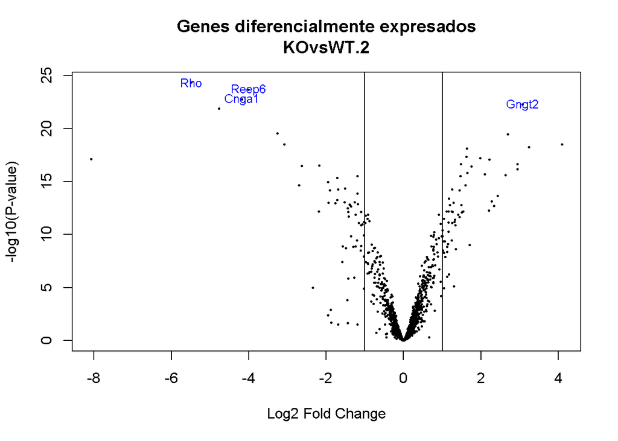

```r
SYMBOLS<- geneSymbols$SYMBOL
volcanoplot(fit.main, coef=1, highlight=4, names=SYMBOLS,
            main=paste("Genes diferencialmente expresados", colnames(cont.matrix)[1], sep="\n"))
  abline(v=c(-1,1))
```

### 3.2.9 Comparación entre distintas comparaciones

Utilizamos un diagrama de Venn para realizar una comparación entre distintas comparaciones.

```r
require(limma)
res<-decideTests(fit.main, method="separate", adjust.method="fdr", p.value=0.1, lfc=1)
```

```r
sum.res.rows<-apply(abs(res),1,sum)
res.selected<-res[sum.res.rows!=0,]
print(summary(res))
```

```
##        KOvsWT.2 KOvsWT.P10 KOvsWT.P2 INT.1 INT.2 INT.3
## Down         58         34         6    32    30    56
## NotSig     2059       2108      2168  2121  2116  2064
## Up           59         34         2    23    30    56
```

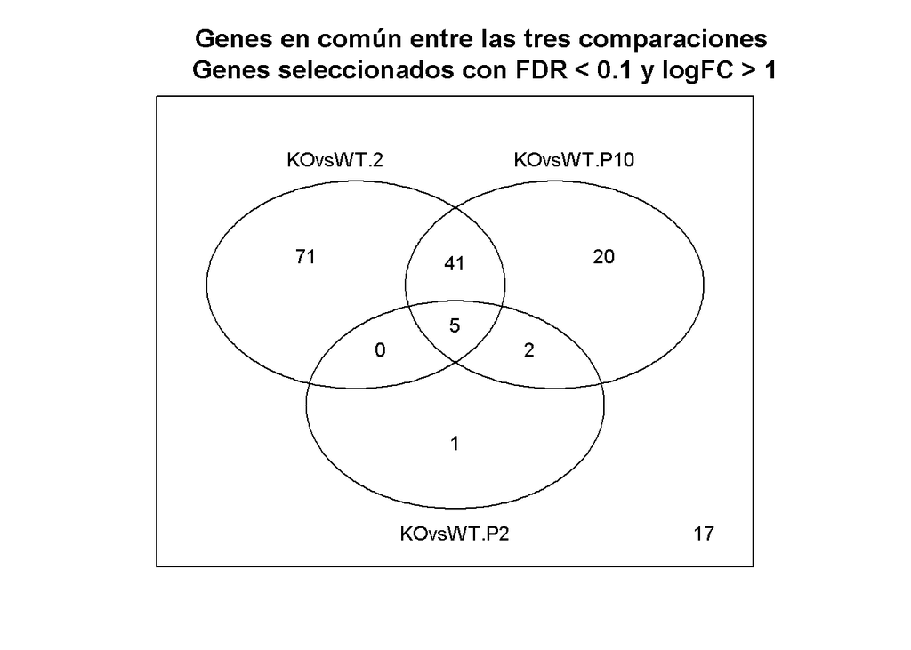

```r
vennDiagram (res.selected[,1:3], cex=0.9)
title("Genes en común entre las tres comparaciones\n Genes seleccionados con FDR < 0.1 y logFC > 1")
```

Además, creamos un “Heatmap” o mapa de colores para ver una agrupación jerárquica de los genes.

```r
probesInHeatmap <- rownames(res.selected)
HMdata <- exprs(esetFiltered)[rownames(exprs(esetFiltered)) %in% probesInHeatmap,]

geneSymbols <- select(mgu74av2.db, rownames(HMdata), c("SYMBOL"))
SYMBOLS<- geneSymbols$SYMBOL
rownames(HMdata) <- SYMBOLS
write.csv(HMdata, file = file.path("./results/data4Heatmap.csv"))
```

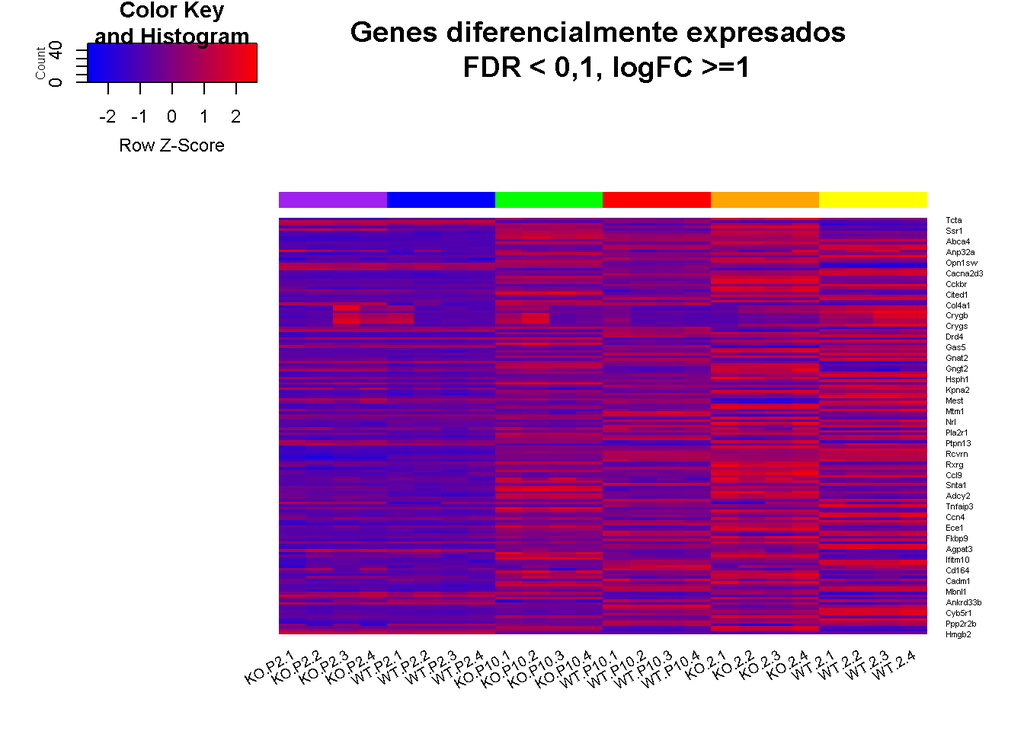

```r
my_palette <- colorRampPalette(c("blue", "red"))(n = 299)
require(gplots)
heatmap.2(HMdata,
          Rowv = FALSE,
          Colv = FALSE,
          main = "Genes diferencialmente expresados \n FDR < 0,1, logFC >=1",
          scale = "row",
          col = my_palette,
          sepcolor = "white",
          sepwidth = c(0.05,0.05),
          cexRow = 0.5,
          cexCol = 0.9,
          key = TRUE,
          keysize = 1.5,
          density.info = "histogram",
          ColSideColors = c(rep("purple", 4), rep("blue", 4), rep("green", 4), rep("red", 4), rep("orange", 4), rep("yellow", 4)),
          tracecol = NULL,
          dendrogram = "none",
          srtCol = 30)
```

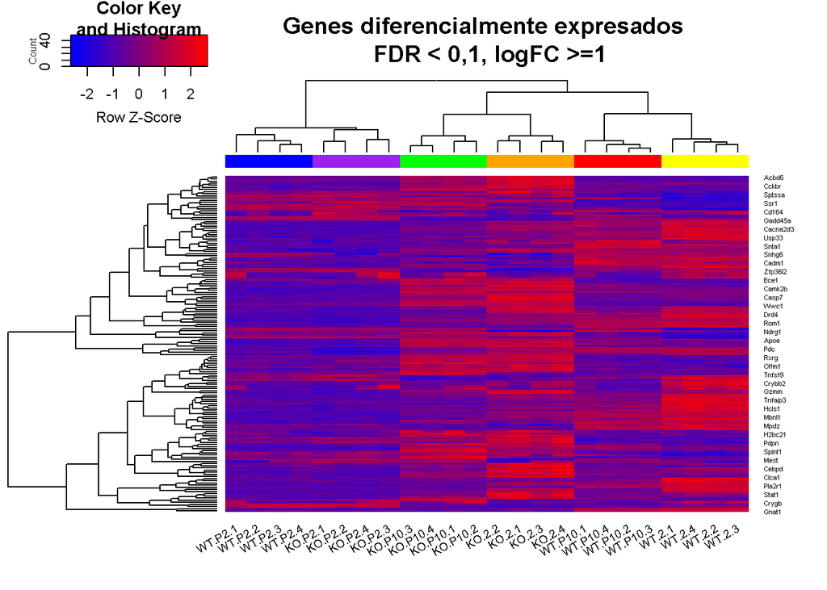

```r
heatmap.2(HMdata,
          Rowv = TRUE,
          Colv = TRUE,
          dendrogram = "both",
          main = "Genes diferencialmente expresados \n FDR < 0,1, logFC >=1",
          scale = "row",
          col = my_palette,
          sepcolor = "white",
          sepwidth = c(0.05,0.05),
          cexRow = 0.5,
          cexCol = 0.9,
          key = TRUE,
          keysize = 1.5,
          density.info = "histogram",
          ColSideColors = c(rep("purple", 4), rep("blue", 4), rep("green", 4), rep("red", 4), rep("orange", 4), rep("yellow", 4)),
          tracecol = NULL,
          srtCol = 30)
```

Si observamos el gráfico “Heatmap”" podemos ver que existen tres agrupaciones: los genes de las condiciones KO y WT de P2, los genes de la condición KO de 2 y P10 y los genes de las condiciones WT de 2 y P10.

### 3.2.10 Análisis de significación biológica

Llevamos a cambo un análisis de la significación biológica mediante análisis de enriquecimiento (“Gene Enrichment Analysis”). Este tipo de análisis se realiza sobre la base de datos de anotaciones “Gene Ontology”. Para que resulte fiable, en este análisis solo se incluyen genes con p-valores ajustados inferiores a 0.05.

```r
require(GOstats)
require(mgu74av2.db)
require(annotate)
listOfTables <- list(KOvsWT2 = topTab_KOvsWT.2, KOvsWTP2 = topTab_KOvsWT.P2, KOvsWTP10 = topTab_KOvsWT.P10, INT1 = topTab_INT.1, INT2 = topTab_INT.2, INT3 = topTab_INT.3)
for (i in 1:length(listOfTables)){
  topTab <- listOfTables[[i]]
  entrezUniverse = unique(getEG(rownames(topTab), "mgu74av2.db"))
  whichGenes<-topTab["adj.P.Val"]<0.05
  geneIds <- unique(getEG(rownames(topTab)[whichGenes],"mgu74av2.db"))
  GOparams = new("GOHyperGParams", geneIds=geneIds,
                 universeGeneIds=entrezUniverse,
                 annotation="mgu74av2.db", ontology="BP",
                 pvalueCutoff=0.001, conditional=FALSE,
                 testDirection="over")
  KEGGparams = new("KEGGHyperGParams", geneIds=geneIds,
                   universeGeneIds=entrezUniverse, annotation="mgu74av2.db",
                   pvalueCutoff=0.01, testDirection="over")
  # Analisis
  GOhyper = hyperGTest(GOparams)
  KEGGhyper = hyperGTest(KEGGparams)
  # Informe html con los resultados
  comparison = names(listOfTables)[i]
  GOfilename =file.path("./results/", paste("GOResults.",comparison,".html",
                                            sep=""))
  KEGGfilename =file.path("./results/", paste("KEGGResults.",
                                              comparison,".html", sep=""))
  htmlReport(GOhyper, file = GOfilename, summary.args=list("htmlLinks"=TRUE))
  htmlReport(KEGGhyper, file = KEGGfilename,
             summary.args=list("htmlLinks"=TRUE))

}
```

[output not shown]

```r
summary(GOhyper)
```

```
##        GOBPID       Pvalue OddsRatio   ExpCount Count Size
## 1  GO:0006952 4.998653e-06  2.191700  36.456819    61  178
## 2  GO:0007601 6.147002e-06  3.886829  10.035866    24   49
## 3  GO:0050953 6.147002e-06  3.886829  10.035866    24   49
## 4  GO:0050896 8.498779e-06  1.610680 231.848985   272 1132
## 5  GO:0007600 8.850994e-06  2.613810  21.095800    40  103
## 6  GO:0009605 5.081645e-05  1.724614  69.226994    97  338
## 7  GO:0007186 8.027667e-05  2.408106  19.866918    36   97
## 8  GO:0050877 1.452657e-04  1.887457  39.324210    60  192
## 9  GO:0150063 2.102498e-04  2.254349  20.686173    36  101
## 10 GO:0048880 2.637740e-04  2.218821  20.890986    36  102
## 11 GO:0009584 3.549619e-04 13.795082   1.843322     7    9
## 12 GO:0009583 3.600476e-04  5.451241   3.891458    11   19
## 13 GO:0046530 3.600476e-04  5.451241   3.891458    11   19
## 14 GO:0001654 3.871468e-04  2.186235  20.481359    35  100
```

[output cut: 23 more lines]

```r
summary(KEGGhyper)
```

```
##   KEGGID       Pvalue OddsRatio ExpCount Count Size              Term
## 1  04744 0.0001267946  11.00985     2.65     9   12 Phototransduction
```

# 4 Resumen de resultados y discusión

Como se ha podido ver desde PCA hasta el Heatmap, la condición KO para 2 y P10 y la condicion WT para 2 y P10 presentan más similitud en la expresión de algunos genes que con las condiciones de P2 o entre las condiciones KO y WT de ratones del mismo grupo de edad. También en el Heatmap se ha visto que la expresión de algunos genes de P2 es más similar para WT y KO que comparando las condiciones de los otros dos grupos de ratones de distinto grupo de edad.

# 5 Problemas y reflexiones durante la realización de la PEC

Es conveniente resaltar que, aunque Bioconductor es una herramienta muy potente y que se implementa muy bien en R, es necesario tener un conocimiento del código a ejecutar, así como unos datos bastante robustos. Precisamente el tema de los datos ha hecho que haya tenido que cambiar de estudio hasta en tres ocasiones. Por otro lado, R Marckdown permite realizar informes con distintos estilos, pero hay pequeños detalles que no he sido capaz de poner, por ejemplo, el tema de los pies de cada imagen o gráfica, ya que no me salían correctamente.

Como reflexión final, me ha parecido una PEC interesante que engloba muy bien todo lo que hemos ido estudiando a lo largo del máster. Aunque el resultado seguramente sea mejorable, creo que es un buen comienzo para empezar a entender las aplicaciones y la importancia de la Bioinformática como disciplina.

# 6 Referencias

Shigeo Yoshida, Alan J. Mears, James S. Friedman, Todd Carter, Shirley He, Edwin Oh, Yuezhou Jing, Rafal Farjo, Gilles Fleury, Carrolee Barlow, Alfred O. Hero, Anand Swaroop, Expression profiling of the developing and mature Nrl −/− mouse retina: identification of retinal disease candidates and transcriptional regulatory targets of Nrl , Human Molecular Genetics, Volume 13, Issue 14, 15 July 2004, Pages 1487–1503, https://doi.org/10.1093/hmg/ddh160

GEO: https://www.ncbi.nlm.nih.gov/geo/query/acc.cgi?acc=GSE8972

GitHub: https://github.com/cferna0256/Bioinformatics/tree/master/PEC_1_CarlosFdez